# Enunciados junto con las soluciones

### Problema 3: Ferran Garcia López

La empresa Jamestown se dedica a la inversión inmobiliaria construyendo, renovando y reacondicionando edificios. Recientemente ha adquirido por 2.000 euros el edificio de una antigua fábrica de bicicletas en el distrito de Schinkel, en Amsterdam. De momento no se han hecho modificaciones, sin embargo el propietario del edificio colindante está interesado en ampliar sus oficinas y ofrece 2.200 euros por el edificio.

Para tomar la decisión también se considera el contexto económico y urbanístico:

- El fenómeno *work-from-home* influye en la demanda de oficinas y no se sabe qué puede ocurrir en un futuro cercano:
  - Si la demanda de oficinas cae, el precio de venta de las oficinas disminuirá un 60%.
  - Si la demanda de oficinas se mantiene, el precio de venta de las oficinas se mantendrá.
- El ayuntamiento pretende renovar las calles e infraestructuras de la zona y se piensa que en un futuro próximo el barrio puede ser más atractivo, repercutiendo en los alquileres y por ende en las transacciones:
  - Si la percepción del barrio mejora, se podrán vender los inmuebles por un 30% más.
  - Si la percepción del barrio empeora, se podrán vender los inmuebles por un 30% menos.

Primero identificamos las alternativas por las que nos podemos decidir:

1. Vender la fábrica ahora
2. Reconvertir la fábrica en oficinas
3. Reconvertir la fábrica en viviendas
4. Esperar sin renovar y vender más tarde

Luego identificamos los estados de la naturaleza:

1. La demanda de oficinas se mantiene y el barrio es más atractivo
2. La demanda de las oficinas cae y el barrio es más atractivo
3. La demanda de las oficinas se mantiene y el barrio es menos atractivo
4. La demanda de las oficinas cae y el barrio es menos atractivo

Después definimos la matriz de decisión, cuyo criterio queremos maximizar:

```r
# DEFINIMOS LOS PARÁMETROS DE LA MATRIZ

pc <- 2000 # precio de compra
pv <- 2200 # precio de venta ahora

bm <- 1.3 # factor precio si la percepción del barrio mejora
be <- .7 # factor precio si la percepción del barrio empeora

do <- .4 # factor precio de las oficinas si su demanda cae

co <- 300 # coste oficinas
apo <- 1000 # aumento de precio por reforma en oficinas

cv <- 1300 # coste viviendas
apv <- 1750 # aumento de precio por reforma en viviendas
```

```r
# DEFINIMOS LA MATRIZ

tbl2 <- crea.tablaX(c(rep(pv - pc, 4),
                 apo*bm - co, apo*do*bm - co, apo*be - co, apo*do*be - co,
                 rep(apv*bm - cv, 2), rep(apv*be - cv, 2),
                 rep(pc*(bm - 1), 2), rep(pc*(be - 1), 2)
                 ), numalternativas = 4)
kable(tbl2)
```

|  | e1 | e2 | e3 | e4 |
| --- | --- | --- | --- | --- |
| d1 | 200 | 200 | 200 | 200 |
| d2 | 1000 | 220 | 400 | -20 |
| d3 | 975 | 975 | -75 | -75 |
| d4 | 600 | 600 | -600 | -600 |

Resolvemos para todos los criterios:

|  | Wald | Optimista | Hurwicz | Savage | Laplace | Punto Ideal |
| --- | --- | --- | --- | --- | --- | --- |
| d1 | 200 | 200 | 200 | 800 | 200 | 1131.6 |
| d2 | -20 | 1000 | 286 | 755 | 400 | 786.4 |
| d3 | -75 | 975 | 240 | 475 | 450 | 549.4 |
| d4 | -600 | 600 | -240 | 1000 | 0 | 1393.1 |
| iAlt.Opt (fav.) | d1 | d2 | d2 | d3 | d3 | d3 |

En conclusión, si no somos muy pesimistas, dudaríamos entre reconvertir la fábrica en oficinas o en viviendas.

### Problema 4: Marco Galliani

Un agricultor de un remoto pueblo al pie del volcan Vesubio tiene que decidir qué hortalizas plantar en su campo. Cada hortaliza lleva asociado un precio de venta (€/kg), un número de unidades que pueden plantarse en el campo y un coeficiente que representa la probabilidad de supervivencia a un clima específico.

| name | price_per_kg | quantity | survival_coeff_clima1 | survival_coeff_clima2 | survival_coeff_clima3 |
| --- | --- | --- | --- | --- | --- |
| Patata | 1.39 | 300 | 0.7 | 0.8 | 0.7 |
| Tomate | 2.40 | 240 | 0.3 | 0.5 | 0.8 |
| Berenjena | 1.84 | 300 | 0.4 | 0.6 | 0.5 |
| Pimientos | 3.12 | 200 | 0.2 | 0.7 | 0.6 |
| Calabacines | 1.88 | 300 | 0.3 | 0.5 | 0.7 |
| Cebolla | 1.46 | 300 | 0.8 | 0.8 | 0.8 |

**Solucion:** Construcion de la tabla decision

```r
temp <- NULL
table_per_lines <- c()

for(i in 1:6){
  temp <- unlist(vegetables[i,4:6]*vegetables[i,2]*vegetables[i,3])
  names(temp) <- NULL
  table_per_lines <- c(table_per_lines, temp)
}
```

Resolucion

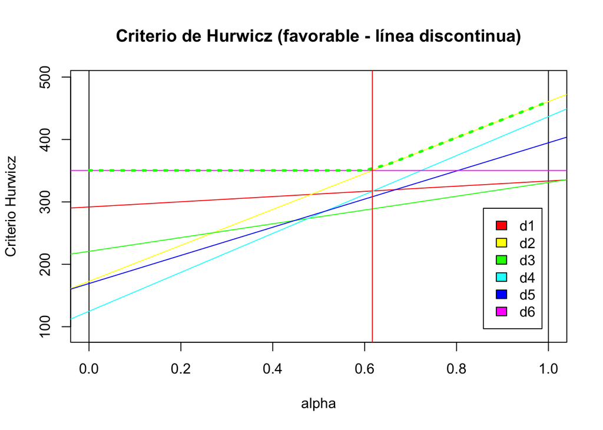

```
## $AltOptimas
## [1] 6 2
##
## $PuntosDeCorte
## [1] 0.617
##
## $IntervalosAlfa
##      Intervalo       Alternativa
## [1,] "( 0 , 0.617 )" "6"
## [2,] "( 0.617 , 1 )" "2"
```

```r
table <- crea.tablaX(table_per_lines,
                     numalternativas = 6,
                     numestados = 3)

dibuja.criterio.Hurwicz_Intervalos(tablaX = table)
```

```r
criterio.Todos(table, alfa = 0.5)
```

```
##                    e1    e2    e3  Wald Optimista Hurwicz Savage Laplace
## d1              291.9 333.6 291.9 291.9     333.6   312.8  168.9   305.8
## d2              172.8 288.0 460.8 172.8     460.8   316.8  177.6   307.2
## d3              220.8 331.2 276.0 220.8     331.2   276.0  184.8   276.0
## d4              124.8 436.8 374.4 124.8     436.8   280.8  225.6   312.0
## d5              169.2 282.0 394.8 169.2     394.8   282.0  181.2   282.0
## d6              350.4 350.4 350.4 350.4     350.4   350.4  110.4   350.4
## iAlt.Opt (fav.)    --    --    --    d6        d2      d6     d6      d6
##                 Punto Ideal
## d1                    206.4
## d2                    231.7
## d3                    249.2
## d4                    241.6
## d5                    247.3
## d6                    140.2
## iAlt.Opt (fav.)          d6
```

**Conclusion:** La mejor opción para el agricultor es cultivar cebollas de acuerdo con todos los criterios de decision considerados, excepto por el criterio optimista y el criterio de Hurwicz con grado de optimismo mayor que 0.617. Si el agricultor es bastante optimista que las condiciones climaticas van a ser buenas entonces eligirà de cultivar tomate por el criterio de Hurwicz y el criterio optimista.